# Final assigment

Kyra Girán (E28OVN)

2022-06-01

#Final assigment

I chose the dataset “Chocolate Ratings” from the 2022/01/18 Tidy Tuesday datasets (https://github.com/rfordatascience/tidytuesday/tree/master/data/2022/2022-01-18)

My idea was, that I would like to build a model, that can help someone planning on establishing a new chocolate brand. They could see which factors influenced the rating that a certain chocolate got.

M hypothesis is, that the more complex second model will be a significantly better fitting one than the first morel. Moreover, I think cocoa percentage will be a significant predictor in the model, since it can greatly define a chocolate’s taste.

##Loading the dataset

```r
chocolate <- readr::read_csv('https://raw.githubusercontent.com/rfordatascience/tidytuesday/master/data/2022/2022-01-18/chocolate.csv')
```

##Data exploration

```
##       ref       company_manufacturer company_location    review_date
##  Min.   :   5   Length:2530          Length:2530        Min.   :2006
##  1st Qu.: 802   Class :character     Class :character   1st Qu.:2012
##  Median :1454   Mode  :character     Mode  :character   Median :2015
##  Mean   :1430                                           Mean   :2014
##  3rd Qu.:2079                                           3rd Qu.:2018
##  Max.   :2712                                           Max.   :2021
##  country_of_bean_origin specific_bean_origin_or_bar_name cocoa_percent
##  Length:2530            Length:2530                      Length:2530
##  Class :character       Class :character                 Class :character
##  Mode  :character       Mode  :character                 Mode  :character
##
##
##
##  ingredients        most_memorable_characteristics     rating
##  Length:2530        Length:2530                    Min.   :1.000
##  Class :character   Class :character               1st Qu.:3.000
##  Mode  :character   Mode  :character               Median :3.250
##                                                    Mean   :3.196
##                                                    3rd Qu.:3.500
##                                                    Max.   :4.000
```

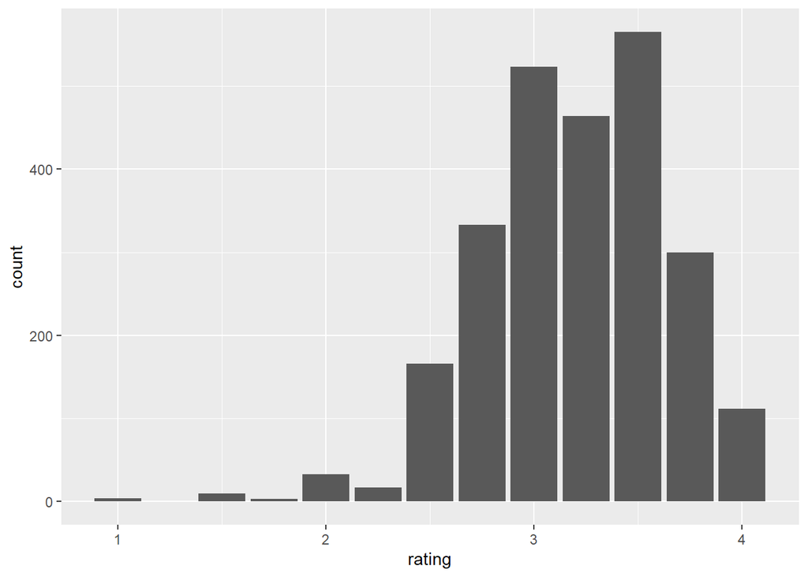

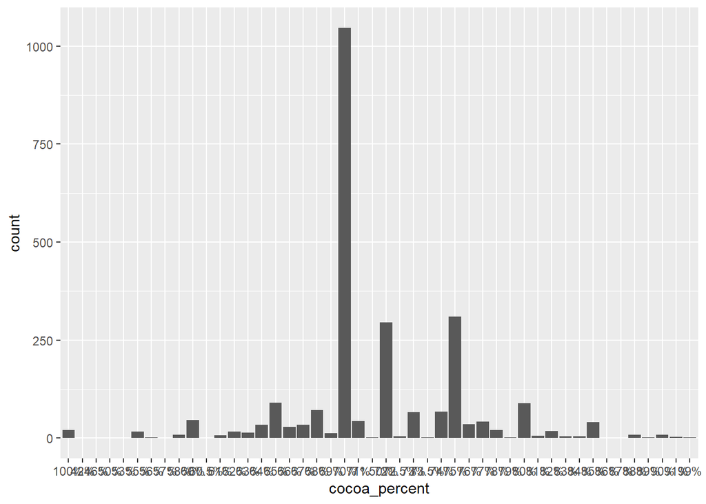

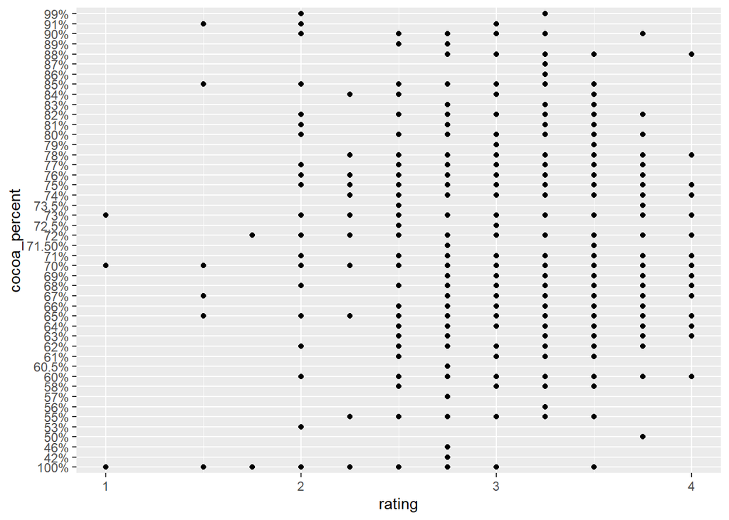

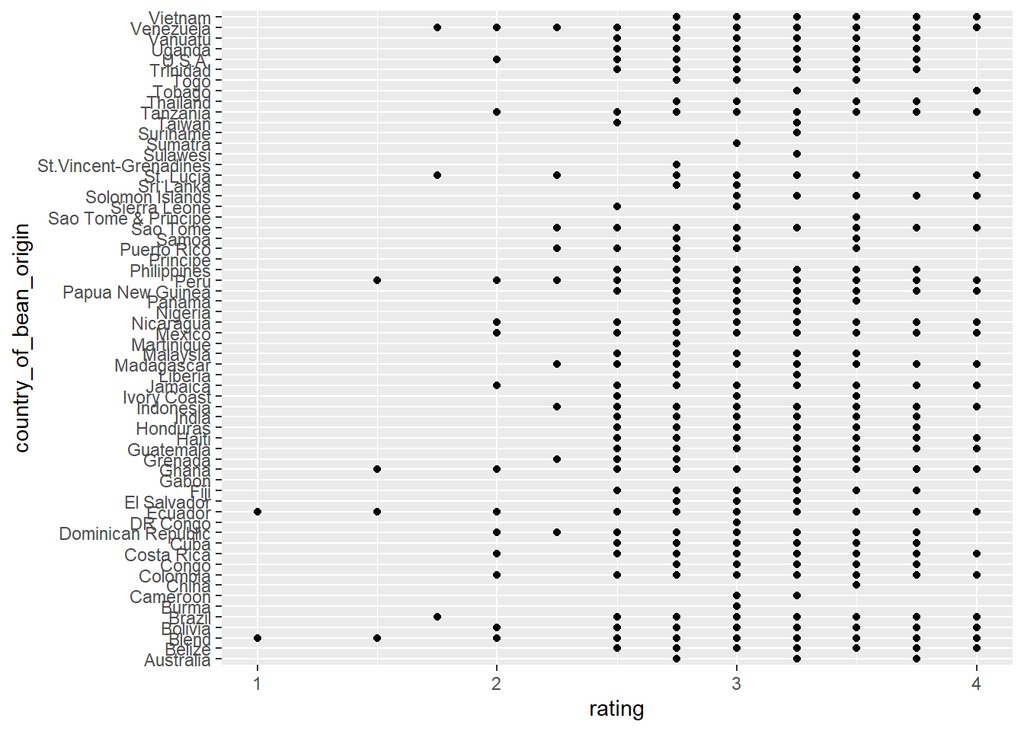

##Data alterations I have extracted how many different ingredients are there in a chocolate based on the ingredients variable. I might use this variable as a predictor.

```r
# extracted how many ingredients there are in a given chocolate
chocolate2 = chocolate %>%
  mutate(ingredient_number = as.integer(stringr::str_extract(ingredients, "\\d+")))
```

I created dummy variables for the components of the ingredient variable. I tought that the different ingredients a chocolate migh have or not have can have a great effect on sujective ratings.

```r
ingr = chocolate2$ingredients

chocolate3 = chocolate2 %>%
  mutate(contains_beans = as.numeric(grepl("B,", ingr))) %>%
  mutate(contains_sugar = as.numeric(grepl("S,", ingr))) %>%
  mutate(contains_cocoabutter = as.numeric(grepl("C", ingr))) %>%
  mutate(contains_vanilla = as.numeric(grepl("V", ingr))) %>%
  mutate(contains_lecithin = as.numeric(grepl("L", ingr))) %>%
  mutate(contains_salt = as.numeric(grepl("Sa", ingr)))
```

The most prominent characteristic might as well provide some help to determine what influences wether we think a chocolate is tasty or not. I searched the most common characteristic in the dataset and created a dummy variable for that taste. This taste turned out to be the sweetness.

```r
# Exploring the most prominent characteristics that might help predict the rating.
#most memorable charactristic split into separate rows

chocolate4 = chocolate3 %>%
  mutate(most_memorable_characteristics=strsplit(most_memorable_characteristics, ",")) %>%
  unnest(most_memorable_characteristics)

chocolate4$most_memorable_characteristics <- trimws(chocolate4$most_memorable_characteristics)

levels(chocolate4$most_memorable_characteristics)
```

```r
table(chocolate4$most_memorable_characteristics)
```

[output not shown]

[output cut: 918 more lines]

[output not shown]

```r
important_characteristics = chocolate4 %>%
  count(most_memorable_characteristics, sort = TRUE)

chocolate5 = chocolate3 %>%
  mutate(sweet_characteristic = as.numeric(grepl("sweet", most_memorable_characteristics)))

# fromatting the cocoa percent variable
chocolate5 = chocolate5 %>%
  mutate_at("cocoa_percent", str_replace, "%", "",) %>%
  mutate(cocoa_percent = as.numeric(cocoa_percent)) %>%
  mutate(rating = as.numeric(rating))
```

The ideal climate for the cocoa bean tree, Theobroma Cacao eis between 20North to 20 South of the Equator according to many papers, for example Fowler and Coutel (2017). To investigate wether these ideal weather conditions can play a part in determinig the cocoa’s and the chocolate’s quality I searched for a dataset which contains the latitude of the world’s countries. I’ve found a pretty exhaustive list, but it is not complete, therefore some countries that are in the country_of_bean_origin variable, are missing from it. That is why it is just an approximate variable. I created a dummy variable, where 1 means that the bean’s origin country is in the right latitude range, and 0 means that it is not. I added this new variable to the chocolate dataset.

Fowler, M. S., & Coutel, F. (2017). Cocoa beans: from tree to factory. Beckett’s industrial chocolate manufacture and use, 9-49.

##Building the models

I built two models, the first one only contains the cocoa percent as a predictor, because that is the first thing we see in a packaging or in the shop, so that is the first information we get about that chocolate. I wanted to compare the more complex model to this simple one, to wether the “first impression” is enough or we need a more detailed list to come closer to determine wether a chocolate is tasty or not.

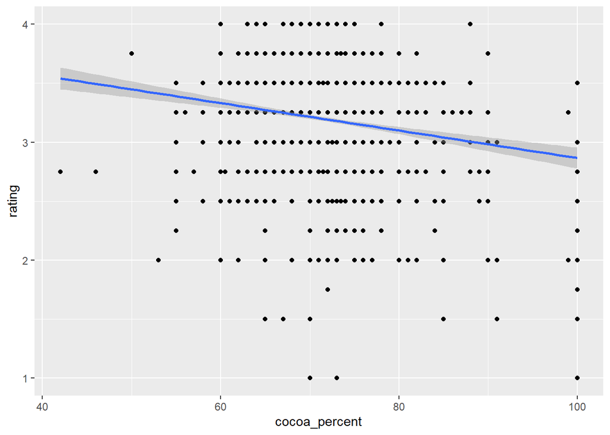

```r
# two linear regression models
model1 = lm(rating ~ cocoa_percent,  data = chocolate6)

chocolate6 %>%
  ggplot() +
  aes(x = cocoa_percent, y = rating) +
  geom_point()+
  geom_smooth(method ="lm")
```

```r
model2 = lm(rating ~ sweet_characteristic + contains_beans +  contains_sugar + contains_cocoabutter + contains_vanilla + contains_lecithin + contains_salt + cocoa_percent  + is_it_right_latitude, data = chocolate6)
```

##Model diagnostics

#Influential outliers There are three influential outliers, that should be sliced from the dataset.

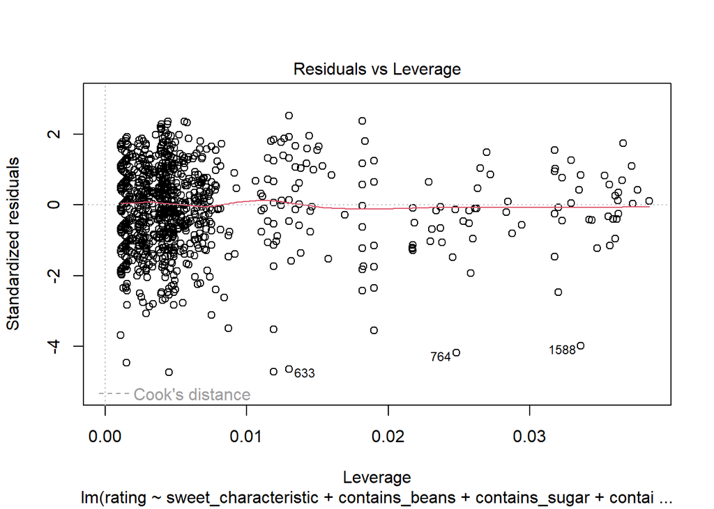

```r
model2%>%
  plot(which = 5)
```

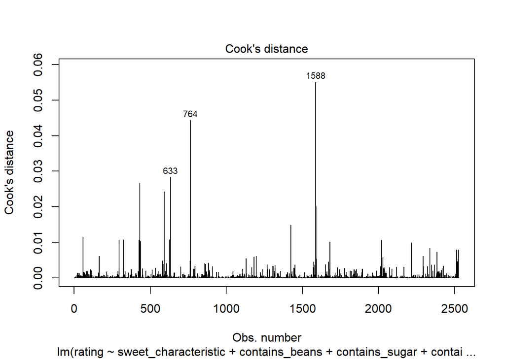

```r
model2%>%
  plot(which = 4)
```

```r
chocolate6_nooutliers = chocolate6 %>%
  slice(-c(1588, 764, 579))
```

#Normality of residuals

The model doesn’t violate the normality of residuals assumption

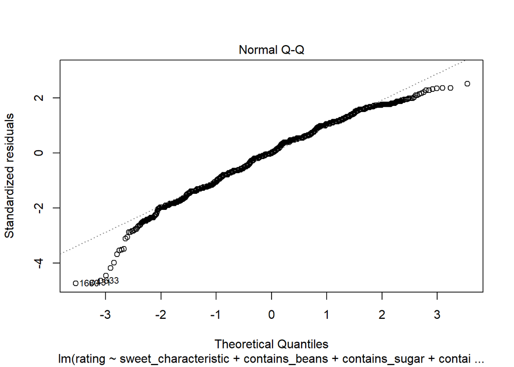

```r
model2 %>%
  plot(which = 2)
```

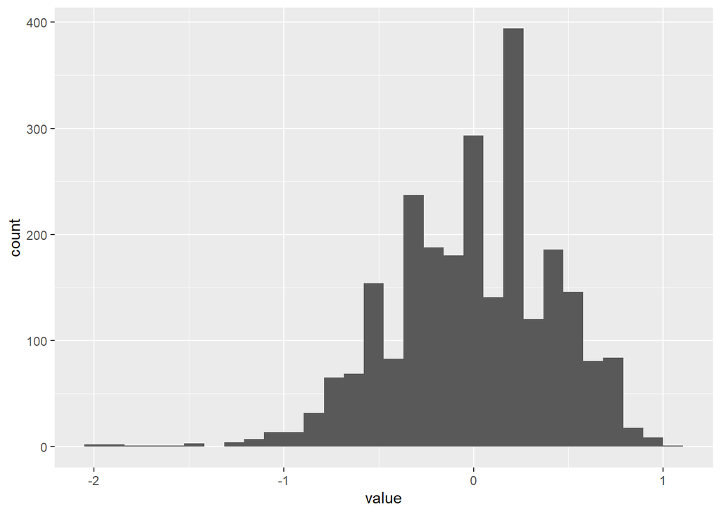

```r
residuals_model2 = enframe(residuals(model2))
residuals_model2 %>%
  ggplot() +
  aes(x = value) +
  geom_histogram()
```

```r
describe(residuals(model2))
```

```
##    vars    n mean   sd median trimmed mad   min  max range  skew kurtosis   se
## X1    1 2530    0 0.42      0    0.01 0.4 -1.99 1.06  3.05 -0.44     0.51 0.01
```

# Linearity

The cocoa percent came back as significant, so it violates the assumption of linear relationship between each predictor variable and the response variable. To solve this violation, I added the second order term of cocoa percent to the final model, but the assumption violation still remained, so I added the third order term of cocoa percent, and that way the violation did not come up again.

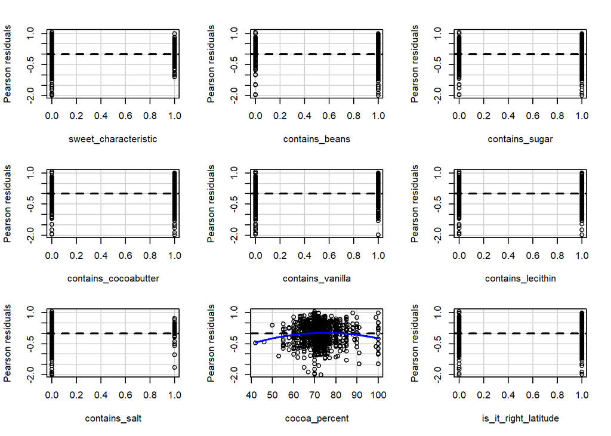

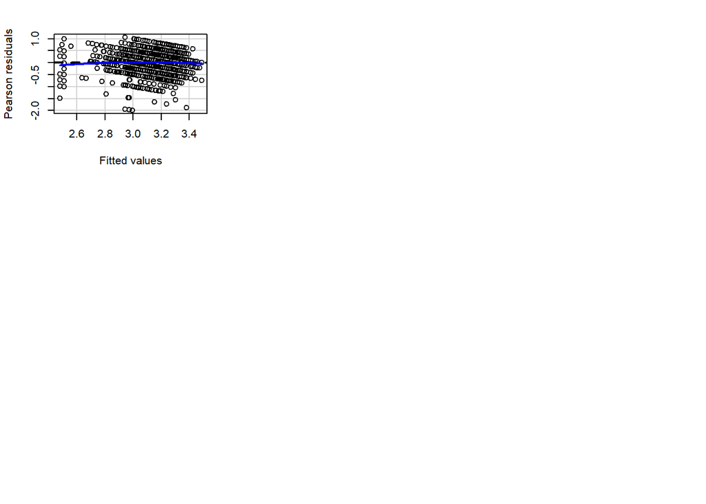

```
##                      Test stat Pr(>|Test stat|)
## sweet_characteristic   -0.6134           0.5397
## contains_beans         -1.2086           0.2269
## contains_sugar          0.8736           0.3824
## contains_cocoabutter    0.7158           0.4742
## contains_vanilla        0.1682           0.8664
## contains_lecithin      -0.3219           0.7476
## contains_salt           0.5111           0.6093
## cocoa_percent          -4.7279        2.393e-06 ***
## is_it_right_latitude   -1.2777           0.2015
## Tukey test             -1.8578           0.0632 .
## ---
## Signif. codes:  0 '***' 0.001 '**' 0.01 '*' 0.05 '.' 0.1 ' ' 1
```

```r
model2 %>%
  residualPlots()
```

#Homoscedasticity

I tested the assumption of equal variance of residuals, but according to the Breusch-Pagan test the model violates this assumption. I tried to take the dependent variable’s log transformed version but the model still violated the assumption of homoscedasticity. Therefore, I will use a robust standard error predicting method such as the Huber-White Sandwich in the final analysis.

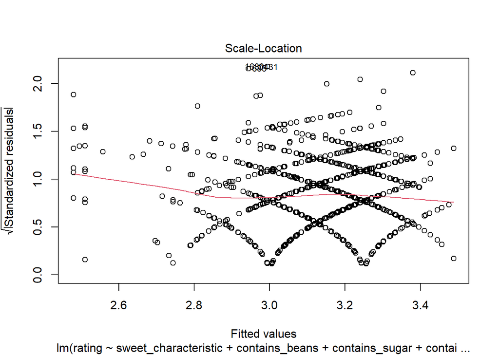

```r
model2 %>%
  plot(which = 3)
```

```r
model2 %>%
  bptest()
```

```
##
##  studentized Breusch-Pagan test
##
## data:  .
## BP = 90.959, df = 9, p-value = 1.045e-15
```

#Multicollinearity

The VIF value is not acceptable in the case of contains_sugar variable and contains_cocoabutter. Therefore I will exclude contains_cocoabutter.

```r
model2 %>%
  vif
```

```
## sweet_characteristic       contains_beans       contains_sugar
##             1.125121             1.122746            12.739920
## contains_cocoabutter     contains_vanilla    contains_lecithin
##            12.493745             1.212826             1.268504
##        contains_salt        cocoa_percent is_it_right_latitude
##             1.230244             1.178527             1.019192
```

## Final models

After checking whether the model violates any of the assumptions of the linear regression, I created the final models which hopefully won’t violate any of the assumptions.

```r
model1_1 = model1 = lm(rating ~ cocoa_percent + I(cocoa_percent^2) + I(cocoa_percent^3),
                     data = chocolate6_nooutliers)

model3 = lm(rating ~ sweet_characteristic + contains_beans +  contains_sugar + contains_vanilla + contains_lecithin + contains_salt + cocoa_percent + I(cocoa_percent^2) + I(cocoa_percent^3) + is_it_right_latitude, data = chocolate6_nooutliers)
```

#Re-checking the assumptions

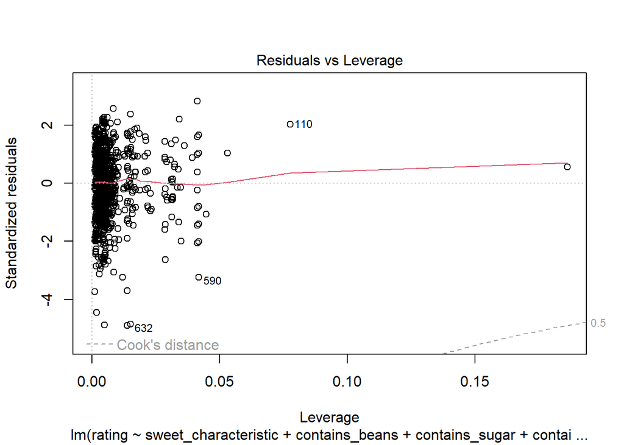

```r
#Influential outliers

model3%>%
  plot(which = 5)
```

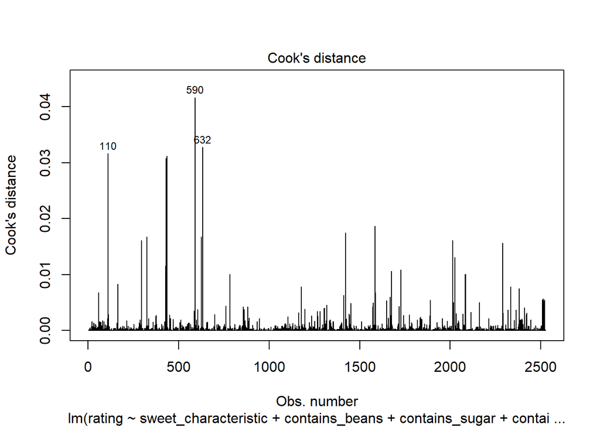

```r
model3%>%
  plot(which = 4)
```

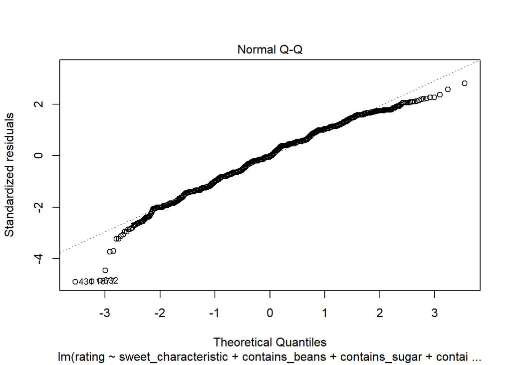

```r
#Normality

model3 %>%
  plot(which = 2)
```

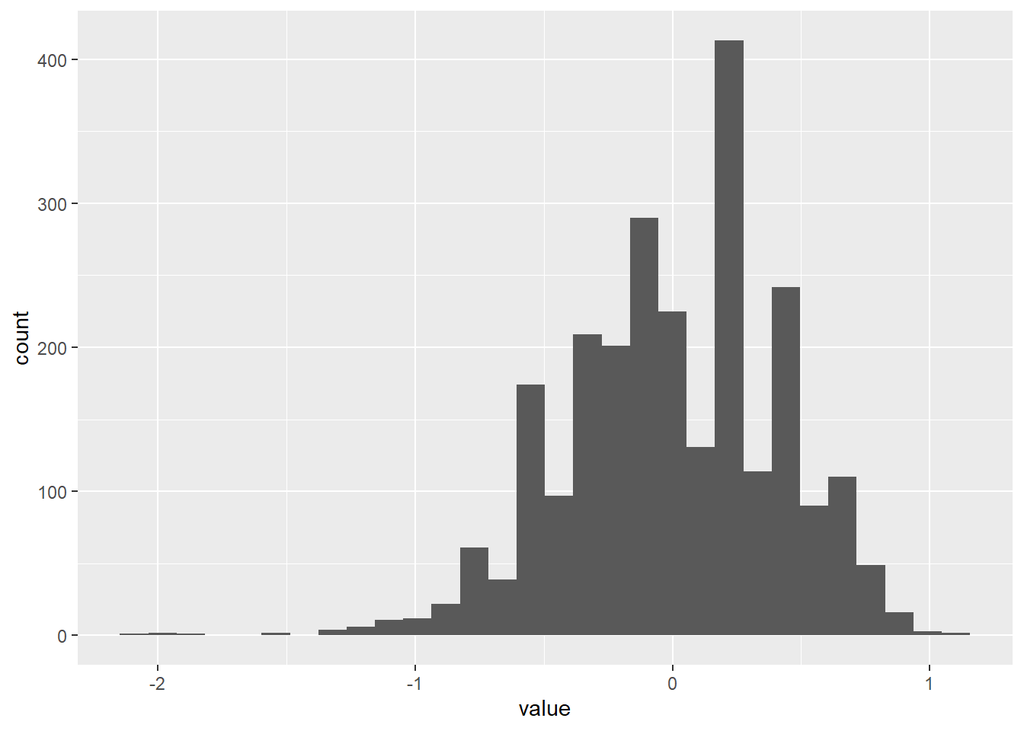

```r
residuals_model3 = enframe(residuals(model3))
residuals_model3 %>%
  ggplot() +
  aes(x = value) +
  geom_histogram()
```

```r
describe(residuals(model3))
```

```
##    vars    n mean   sd median trimmed  mad   min  max range skew kurtosis   se
## X1    1 2527    0 0.42  -0.01    0.01 0.41 -2.04 1.15  3.19 -0.4     0.44 0.01
```

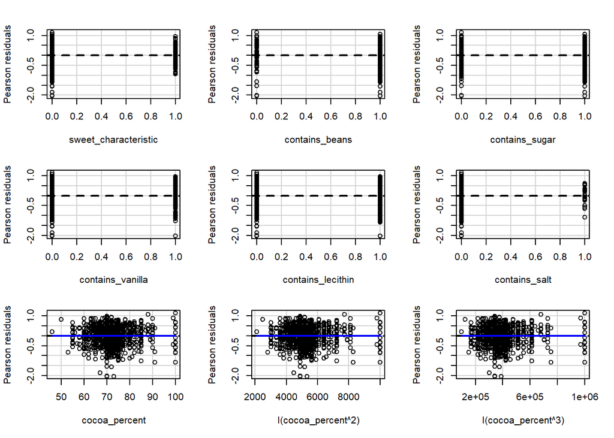

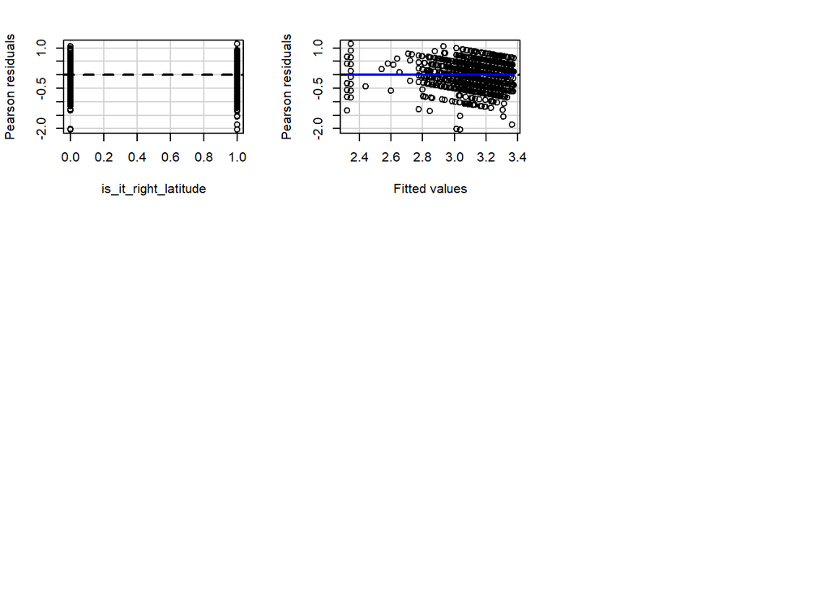

```
##                      Test stat Pr(>|Test stat|)
## sweet_characteristic    0.6219           0.5341
## contains_beans         -1.2174           0.2236
## contains_sugar         -0.8607           0.3895
## contains_vanilla       -0.7372           0.4611
## contains_lecithin      -0.2398           0.8105
## contains_salt          -0.3521           0.7248
## cocoa_percent          -0.9701           0.3321
## I(cocoa_percent^2)     -1.2963           0.1950
## I(cocoa_percent^3)     -1.4822           0.1384
## is_it_right_latitude   -1.2992           0.1940
## Tukey test             -0.0320           0.9745
```

```r
#Linearity solution

model3 %>%
  residualPlots()
```

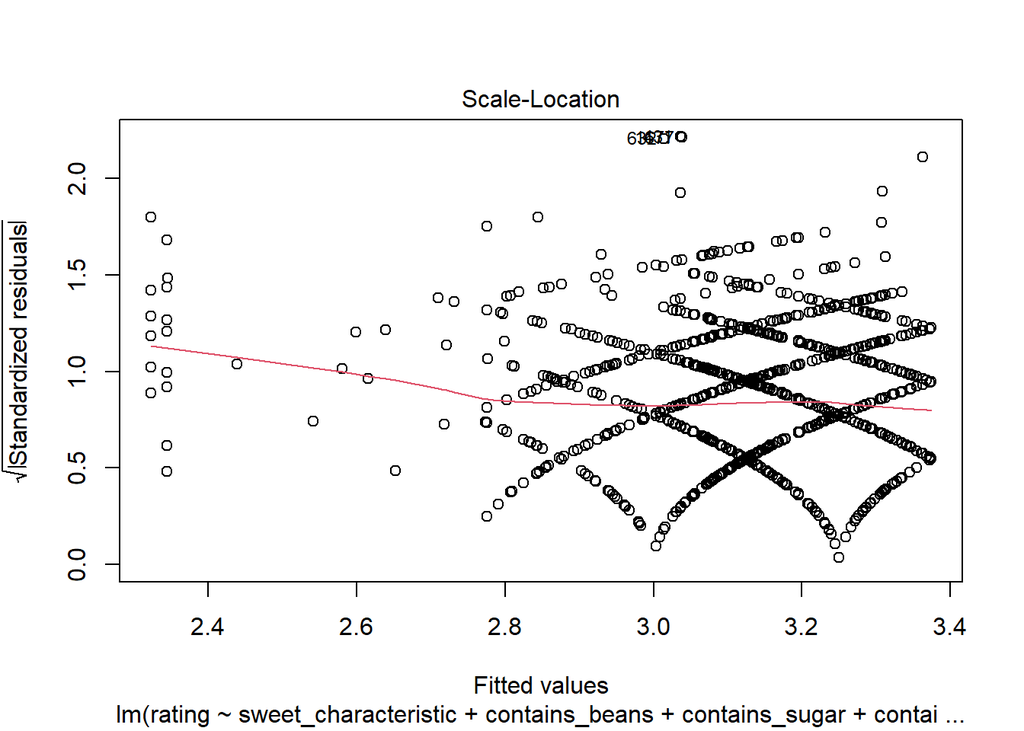

```r
#Homoscedasticity

model3 %>%
  plot(which = 3)
```

```r
model3 %>%
  bptest()
```

```
##
##  studentized Breusch-Pagan test
##
## data:  .
## BP = 96.669, df = 10, p-value = 2.524e-16
```

```r
#Multicollinearity

model3 %>%
  vif()
```

```
## sweet_characteristic       contains_beans       contains_sugar
##             1.228724             1.337604             1.261978
##     contains_vanilla    contains_lecithin        contains_salt
##             1.231902             1.278488             1.011578
##        cocoa_percent   I(cocoa_percent^2)   I(cocoa_percent^3)
##          7531.764913         29977.322747          7686.165480
## is_it_right_latitude
##             1.019799
```

## Results

```r
summary(model3)
```

```
##
## Call:
## lm(formula = rating ~ sweet_characteristic + contains_beans +
##     contains_sugar + contains_vanilla + contains_lecithin + contains_salt +
##     cocoa_percent + I(cocoa_percent^2) + I(cocoa_percent^3) +
##     is_it_right_latitude, data = chocolate6_nooutliers)
##
## Residuals:
##      Min       1Q   Median       3Q      Max
## -2.03809 -0.28120 -0.00867  0.27010  1.15476
##
## Coefficients:
##                        Estimate Std. Error t value Pr(>|t|)
## (Intercept)          -4.401e+00  3.244e+00  -1.357  0.17503
## sweet_characteristic -1.938e-01  2.781e-02  -6.971 4.00e-12 ***
## contains_beans        2.354e-01  5.104e-02   4.613 4.17e-06 ***
## contains_sugar        6.308e-02  1.956e-02   3.226  0.00127 **
## contains_vanilla     -2.059e-01  2.663e-02  -7.732 1.52e-14 ***
## contains_lecithin    -2.702e-02  2.374e-02  -1.138  0.25522
## contains_salt        -1.136e-01  7.052e-02  -1.612  0.10719
## cocoa_percent         2.872e-01  1.291e-01   2.225  0.02617 *
## I(cocoa_percent^2)   -3.500e-03  1.704e-03  -2.054  0.04012 *
## I(cocoa_percent^3)    1.300e-05  7.432e-06   1.749  0.08036 .
## is_it_right_latitude  2.195e-02  1.935e-02   1.134  0.25685
## ---
## Signif. codes:  0 '***' 0.001 '**' 0.01 '*' 0.05 '.' 0.1 ' ' 1
##
## Residual standard error: 0.4177 on 2516 degrees of freedom
## Multiple R-squared:  0.1143, Adjusted R-squared:  0.1108
## F-statistic: 32.48 on 10 and 2516 DF,  p-value: < 2.2e-16
```

```r
#library(devtools)
#install_github("DoseResponse/drc")

# compute robust SE and p-values
model3_sandwich_test = coeftest(model3, vcov = vcovHC, type = "HC")

model3_sandwich_test
```

```
##
## t test of coefficients:
##
##                         Estimate  Std. Error t value  Pr(>|t|)
## (Intercept)          -4.4014e+00  3.5869e+00 -1.2271 0.2199071
## sweet_characteristic -1.9384e-01  2.3218e-02 -8.3489 < 2.2e-16 ***
## contains_beans        2.3543e-01  6.7417e-02  3.4922 0.0004873 ***
## contains_sugar        6.3081e-02  1.8260e-02  3.4546 0.0005603 ***
## contains_vanilla     -2.0593e-01  2.8559e-02 -7.2106 7.337e-13 ***
## contains_lecithin    -2.7021e-02  2.4521e-02 -1.1020 0.2705844
## contains_salt        -1.1364e-01  6.4455e-02 -1.7631 0.0780033 .
## cocoa_percent         2.8721e-01  1.4509e-01  1.9796 0.0478587 *
## I(cocoa_percent^2)   -3.4997e-03  1.9511e-03 -1.7937 0.0729752 .
## I(cocoa_percent^3)    1.3001e-05  8.6891e-06  1.4962 0.1347267
## is_it_right_latitude  2.1950e-02  1.9497e-02  1.1258 0.2603416
## ---
## Signif. codes:  0 '***' 0.001 '**' 0.01 '*' 0.05 '.' 0.1 ' ' 1
```

```r
model3_sandwich_test_se = unclass(model3_sandwich_test)[,2]

# compute robust confidence intervals
CI95_lb_robust = coef(model3)-1.96*model3_sandwich_test_se

CI95_ub_robust = coef(model3)+1.96*model3_sandwich_test_se

cbind(model3_sandwich_test, CI95_lb_robust, CI95_ub_robust)
```

```
##                           Estimate   Std. Error   t value     Pr(>|t|)
## (Intercept)          -4.401367e+00 3.586860e+00 -1.227081 2.199071e-01
## sweet_characteristic -1.938416e-01 2.321775e-02 -8.348853 1.122452e-16
## contains_beans        2.354350e-01 6.741721e-02  3.492208 4.873015e-04
## contains_sugar        6.308124e-02 1.826013e-02  3.454590 5.602528e-04
## contains_vanilla     -2.059275e-01 2.855916e-02 -7.210558 7.336807e-13
## contains_lecithin    -2.702121e-02 2.452104e-02 -1.101960 2.705844e-01
## contains_salt        -1.136409e-01 6.445479e-02 -1.763110 7.800328e-02
## cocoa_percent         2.872085e-01 1.450850e-01  1.979588 4.785871e-02
## I(cocoa_percent^2)   -3.499678e-03 1.951054e-03 -1.793737 7.297521e-02
## I(cocoa_percent^3)    1.300058e-05 8.689062e-06  1.496201 1.347267e-01
## is_it_right_latitude  2.195001e-02 1.949661e-02  1.125838 2.603416e-01
##                      CI95_lb_robust CI95_ub_robust
## (Intercept)           -1.143161e+01   2.628879e+00
## sweet_characteristic  -2.393484e-01  -1.483348e-01
## contains_beans         1.032972e-01   3.675727e-01
## contains_sugar         2.729139e-02   9.887109e-02
## contains_vanilla      -2.619035e-01  -1.499515e-01
## contains_lecithin     -7.508244e-02   2.104002e-02
## contains_salt         -2.399723e-01   1.269049e-02
## cocoa_percent          2.841864e-03   5.715752e-01
## I(cocoa_percent^2)    -7.323745e-03   3.243884e-04
## I(cocoa_percent^3)    -4.029979e-06   3.003115e-05
## is_it_right_latitude  -1.626334e-02   6.016336e-02
```

```r
summ(model3,
  robust = getOption("summ-robust", TRUE))
```

```
## MODEL INFO:
## Observations: 2527
## Dependent Variable: rating
## Type: OLS linear regression
##
## MODEL FIT:
## F(10,2516) = 32.48, p = 0.00
## R² = 0.11
## Adj. R² = 0.11
##
## Standard errors: Robust, type = HC3
## ---------------------------------------------------------
##                               Est.   S.E.   t val.      p
## -------------------------- ------- ------ -------- ------
## (Intercept)                  -4.40   3.74    -1.18   0.24
## sweet_characteristic         -0.19   0.02    -8.28   0.00
## contains_beans                0.24   0.07     3.44   0.00
## contains_sugar                0.06   0.02     3.45   0.00
## contains_vanilla             -0.21   0.03    -7.16   0.00
## contains_lecithin            -0.03   0.02    -1.10   0.27
## contains_salt                -0.11   0.07    -1.71   0.09
## cocoa_percent                 0.29   0.15     1.90   0.06
## I(cocoa_percent^2)           -0.00   0.00    -1.72   0.08
## I(cocoa_percent^3)            0.00   0.00     1.44   0.15
## is_it_right_latitude          0.02   0.02     1.12   0.26
## ---------------------------------------------------------
```

```r
summ(model1_1)
```

```
## MODEL INFO:
## Observations: 2527
## Dependent Variable: rating
## Type: OLS linear regression
##
## MODEL FIT:
## F(3,2523) = 56.48, p = 0.00
## R² = 0.06
## Adj. R² = 0.06
##
## Standard errors: OLS
## -------------------------------------------------------
##                             Est.   S.E.   t val.      p
## ------------------------ ------- ------ -------- ------
## (Intercept)                -8.41   3.18    -2.64   0.01
## cocoa_percent               0.41   0.13     3.23   0.00
## I(cocoa_percent^2)         -0.00   0.00    -2.72   0.01
## I(cocoa_percent^3)          0.00   0.00     2.09   0.04
## -------------------------------------------------------
```

```r
AIC(model1_1)
```

```
## [1] 2900.384
```

```r
AIC(model3)
```

```
## [1] 2771.843
```

All in all, I would advise someone who plans to open a chocolate factory, to keep an eye on the sweetness, the sugar content, the vanilla extract content and the cocoa percent of the chocolate. With the addition, that the less sweet tasting and less vanilla tasting a chocolate is, the better rating it will get.